# Predicting the gross of top 1000 movies in IMDB

### Certificate

Movies are certified by its suitability for certain audience based on its content, so we can assume that movie certificate are related to the genre of the movie. Let’s create a frequency table of certificate types based on the primary genre.

```r
# table of certificate frequency for each primary genre
certificate_freq <- table(imdb$primary_genre, imdb$certificate)
certificate_freq <- as.data.frame.matrix(certificate_freq)

# mode for each genre
mode_certificates <- apply(certificate_freq, 1, function(x) names(x)[which.max(x)])

# dataframe of certificate counts and mode
merged_data <- cbind(certificate_freq, Mode = mode_certificates)
merged_data
```

```
##            A  U UA Mode
## Action    50 16 71   UA
## Adventure 14 31 16    U
## Animation  3 55  8    U
## Biography 31 28 20    A
## Comedy    46 44 32    A
## Crime     62  7 16    A
## Drama     96 50 64    A
## Family     0  2  0    U
## Film-Noir  0  0  1   UA
## Horror     7  0  2    A
## Mystery    5  2  2    A
## Thriller   0  0  0    A
## Western    2  2  0    A
```

Lets fill in the missing certificate with the mode based on its primary genre.

```r
for (i in 1:length(unique(imdb$primary_genre))) {
  genre <- unique(imdb$primary_genre)[i]
  mode_cert <- mode_certificates[i]
  imdb$certificate[imdb$primary_genre == genre & is.na(imdb$certificate)] <- mode_cert
}

sum(is.na(imdb$certificate))
```

```
## [1] 0
```

Now let’s check if we have handled all the missing values in the data set.

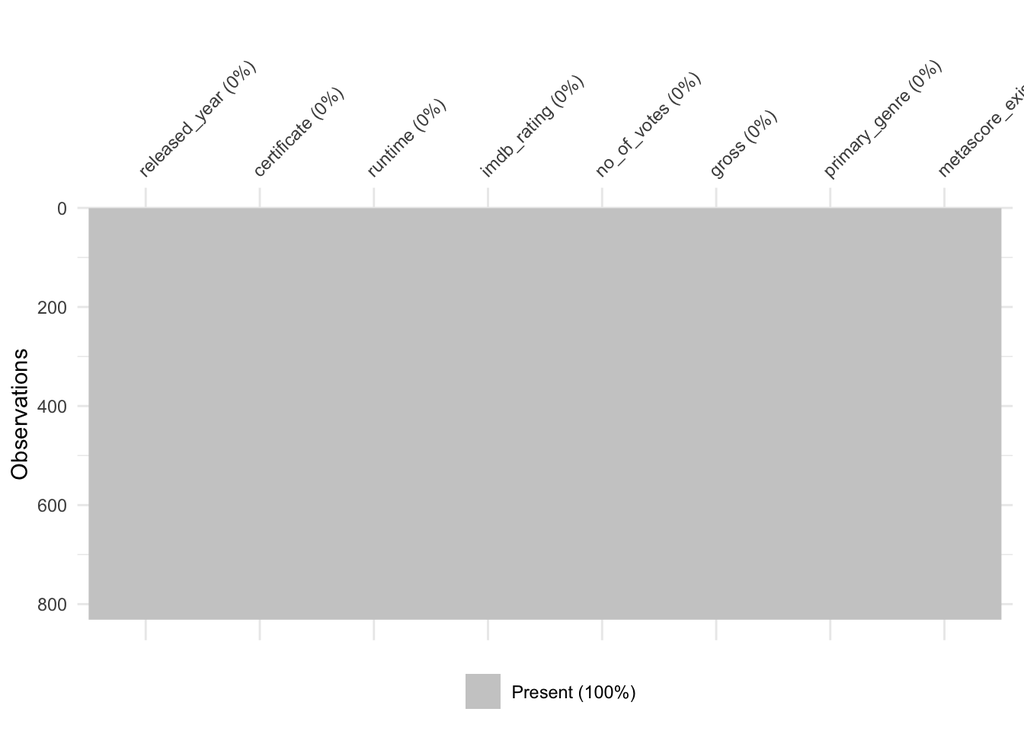

```r
imdb %>%
  vis_miss()
```

Now our dataset has no missing values. Let’s look at the five point summary for the numeric variables.

```r
select_if(imdb, is.numeric) %>% describe()
```

```
##               vars   n    mean     sd  median trimmed    mad     min     max
## released_year    1 831 1993.92  21.14 2000.00 1996.89  17.79 1921.00 2019.00
## runtime          2 831  124.08  27.50  120.00  121.60  25.20   45.00  242.00
## imdb_rating      3 831    7.95   0.28    7.90    7.92   0.30    7.60    9.30
## no_of_votes      4 831  315.25 343.64  186.73  250.56 202.64   25.09 2343.11
## gross            5 831   68.03 109.75   23.53   43.49  33.75    0.00  936.66
##                 range  skew kurtosis    se
## released_year   98.00 -1.18     0.82  0.73
## runtime        197.00  0.96     1.41  0.95
## imdb_rating      1.70  1.08     1.51  0.01
## no_of_votes   2318.02  2.07     5.62 11.92
## gross          936.66  3.12    13.78  3.81
```

After cleaning the data, we ended up with 831 movies and 8 variables. Our dataset contains 5 numeral variables and 3 categorical variables. Looks like the average gross revenue is around 68 million with 936 million as the maximum gross for a movie and 0 as minimum.

## Data visualization

First, we need to convert all the categorical variables to factors.

```r
# Changing categorical variables to factors
imdb <- imdb %>%
  mutate(certificate = factor(certificate),
        primary_genre = factor(primary_genre),
        metascore_exists = factor(metascore_exists))
```

### Correlation Plot

Let’s explore the overall correlation between the continuous variables.

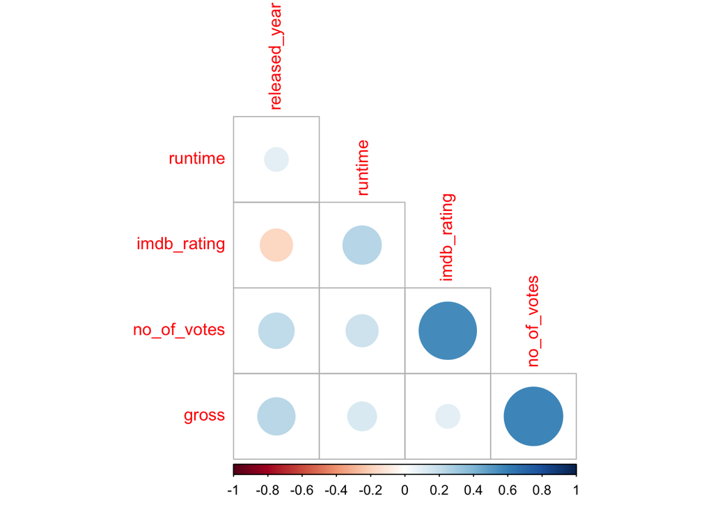

```r
imdb %>%
  select(is.numeric) %>%
  cor(use = "complete.obs") %>%
  corrplot(type = 'lower', diag = FALSE,
           method = 'circle')
```

There’s strong positive correlation between variables `no_of_votes` and `imdb_rating`. It makes sense the movies that get more votes gets higher score in `imdb_rating`. There’s also strong correlation between `gross` and `no_of_votes`. So movies that gets higher votes tend to do better in revenue. Which makes sense since higher votes means higher popularity, and we can assume that higher popularity in movies will do better in gross revenue. There’s also positive correlation between movie `released_ year` and `gross`, so newer movies tend to get higher gross. This also makes sense since cinema prices increases overtime.

### Gross revenue

Let’s explore the distribution of our outcome variable `gross`.

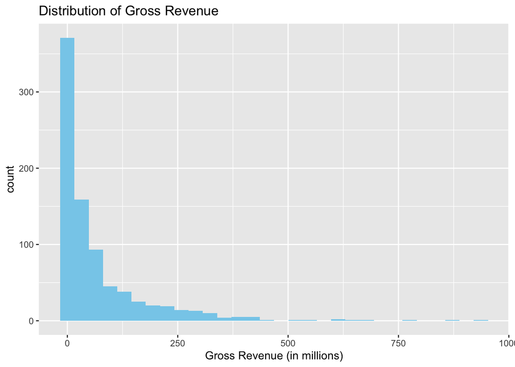

```r
# Distribution of gross revenue
imdb %>% ggplot(aes(gross)) +
  geom_histogram(fill='skyblue') +
  labs(title = 'Distribution of Gross Revenue',
       x = 'Gross Revenue (in millions)'
  )
```

### Certificate

We grouped the certificate types into 3 classes, “U”, “UA”, and “A”. Let’s take a look at it’s relationship with gross revenue and see if certain certificate types have higher gross revenue than others.

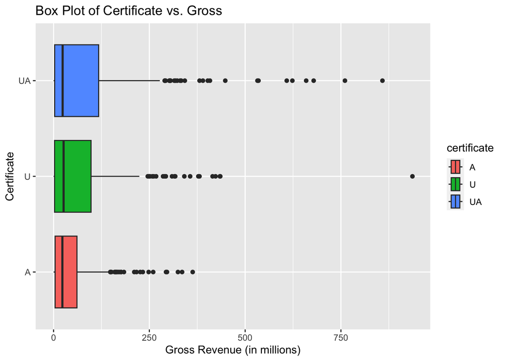

```r
# Boxplot of Gross and Certificate
imdb %>%
  ggplot(aes(x=gross, y=certificate, fill=certificate)) +
  geom_boxplot() + labs(title="Box Plot of Certificate vs. Gross",
                        y='Certificate',
                        x='Gross Revenue (in millions)')
```

The plot shows the quantiles and medians of gross revenues of different certificate types. It shows that the gross revenue of movies with UA certificate ranges the most and have a higher third quantile on average compare to the other certificate types. Most outliers also come from the UA rated movies. This makes sense since UA rating are suitable for a wider audience.

### Primary Genre and Gross

Let’s visualize the relationship between genre and gross revenue.

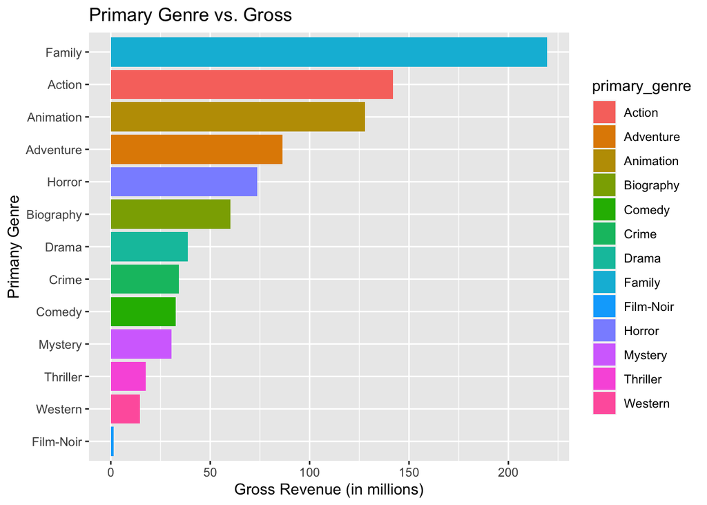

```r
# calculate gross revenue average for each primary genre
genre_mean <- aggregate(gross ~ primary_genre, imdb, mean)

genre_mean %>%
  ggplot(aes(x=reorder(primary_genre, gross), y=gross, fill= primary_genre)) +
  geom_bar(stat="identity") + coord_flip( ) +
  labs(title="Primary Genre vs. Gross ",
       x = 'Primany Genre',
       y = 'Gross Revenue (in millions)')
```

There is a total of 13 primary genres. On average the family genre gets the highest gross revenue, and the film-noir genre gets the lowest gross revenue. The top 3 genres are Family, Action and animation. The genres that tend to do worse in revenue is thriller, western and film-noir.

### Released Years

Let’s visualize the relationship of `gross` and `released_year`.

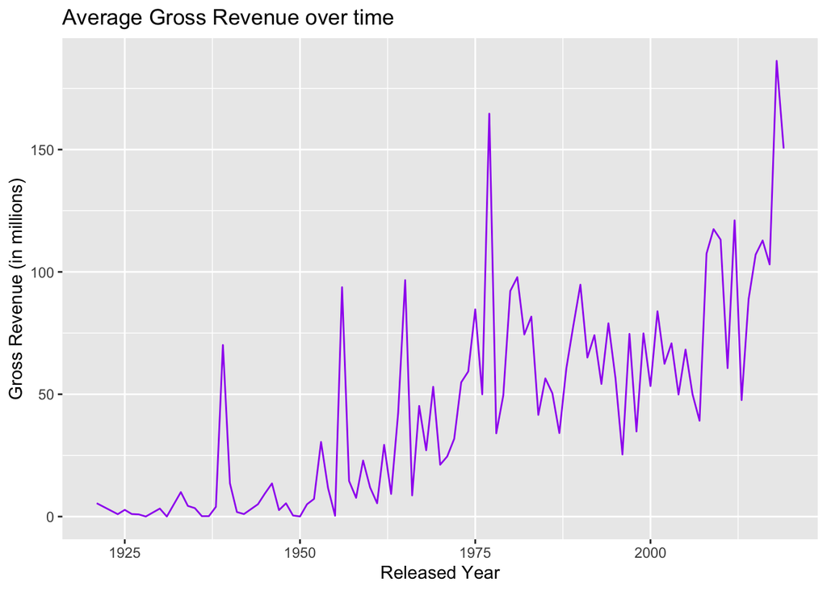

```r
# calculate gross revenue average over time
year_mean <- aggregate(gross ~ released_year, imdb, mean)

year_mean %>%
  ggplot(aes(x=released_year, y=gross)) +
  geom_line(col='purple') +
  labs(title="Average Gross Revenue over time",
       x="Released Year",
       y="Gross Revenue (in millions)")
```

Gross revenue has fluctuated over the years but there’s a clear upward trend. Which makes sense since cinema prices increases overtime and the filming industry/market is growing overtime. Notably, there’s a significant spike around 1975 where revenue surpasses 150 million. However this peak is not replicated until recent years.

# Model Building

## Split data

First, let’s split the data into training and testing set. The training set is used for training our models and the testing set is used in the end to test how well our models predict the outcome variable on unseen data. I split the data into 70/30, 70% are used in training and 30% of the data are used for testing.

```r
set.seed(123)

# split the data by 70% stratify on gross
imdb_split <- initial_split(imdb, prop = 0.70,
                                strata = gross)
imdb_train <- training(imdb_split)
imdb_test <- testing(imdb_split)

imdb_split
```

```
## <Training/Testing/Total>
## <579/252/831>
```

## Write the recipe

```r
# creating recipe
imdb_recipe <- recipe(gross ~ ., data = imdb_train) %>%
  # dummy coding all nominal variables
  step_dummy(all_nominal_predictors()) %>%
  step_zv(all_predictors()) %>%
  # scaling
  step_center(all_predictors()) %>%
  step_scale(all_predictors())

imdb_recipe %>%
  prep() %>%
  bake(new_data = imdb_train)
```

```
## # A tibble: 579 × 19
##    released_year runtime imdb_rating no_of_votes  gross certificate_U
##            <dbl>   <dbl>       <dbl>       <dbl>  <dbl>         <dbl>
##  1        -1.92   2.97          2.32    -0.00742 0.269          1.57
##  2        -3.01  -1.35          1.97    -0.430   0.0192         1.57
##  3         1.14   0.0514        1.61    -0.731   1.66          -0.636
##  4         0.613  1.46          1.61    -0.427   1.22           1.57
##  5         0.422 -0.850         1.61     0.564   0.707         -0.636
##  6         0.136  0.340         1.61     0.0710  2.38           1.57
##  7        -1.44  -1.07          1.61     0.378   0.276         -0.636
##  8         0.136 -1.28          1.25    -0.723   0.934          1.57
##  9        -0.103 -0.922         1.25     1.72    2.83          -0.636
## 10        -2.01   0.664         1.25    -0.714   0.0552        -0.636
## # ℹ 569 more rows
## # ℹ 13 more variables: certificate_UA <dbl>, primary_genre_Adventure <dbl>,
## #   primary_genre_Animation <dbl>, primary_genre_Biography <dbl>,
## #   primary_genre_Comedy <dbl>, primary_genre_Crime <dbl>,
## #   primary_genre_Drama <dbl>, primary_genre_Film.Noir <dbl>,
## #   primary_genre_Horror <dbl>, primary_genre_Mystery <dbl>,
## #   primary_genre_Thriller <dbl>, primary_genre_Western <dbl>, …
```

## K-fold Cross Validation

We will create 10 folds for k-fold stratified cross validation. This means that the dataset is divided into 10 equally folds into validation sets with each fold being a testing set with the other k-1 folds being the training set for that fold. After each training-validation iteration, the average accuracy is taken from the testing set of each of the folds to evaluate the performance of the model. By using k-fold cross validation, we can get a more reliable and stable estimate of the model’s performance to new unseen data.

We stratify on the outcome variable `gross` to ensure we fold the data proportionally.

```r
imdb_folds <- vfold_cv(imdb_train, v=10, strata = gross)
```

## Setting up models

Now let’s start setting up our models! We will be building five models, linear regression, k-nearest neighbors, elastic net, random forest and boosted tree. Since some models will take very long time to run, I will save each model result to avoid needing to rerun the models every time. After fitting the models I will evaluate their performances with Root Mean Squared Error (RMSE). RMSE measures how far the model’s predictions are from the true values using Euclidian distance, it is one of the most commonly used metric for evaluating the performance of regression models.

Setting up models by specifying the model, setting up appropriate mode and engine, as well as the parameters we want to tune.

```r
# Linear Regression
lm_model <- linear_reg() %>%
  set_engine("lm")

# K-Nearest Neighbors Model
knn_model <- nearest_neighbor(neighbors = tune()) %>%
  set_engine("kknn") %>%
  set_mode("regression")

# Elastic Net
# Tuning penalty and mixture
en_spec <- linear_reg(penalty = tune(),
                           mixture = tune()) %>%
  set_engine("glmnet") %>%
  set_mode("regression")

# Random Forest
# Tuning mtry (number of predictors), trees, and min_n (number of minimum values in each node)
rf_spec <- rand_forest(mtry = tune(),
                       trees = tune(),
                       min_n = tune()) %>%
  set_engine("ranger", importance = "impurity") %>%
  set_mode("regression")

# Boosted tree
# Tuning mtry (number of predictors), trees, and learning rate
bt_spec <- boost_tree(mtry = tune(),
                           trees = tune(),
                           learn_rate = tune()) %>%
  set_engine("xgboost") %>%
  set_mode("regression")
```

### Setting up workflow

Let’s set up the workflow for each model and add the model and the recipe.

```r
# Linear Regression
lm_wflow <- workflow() %>%
  add_model(lm_model) %>%
  add_recipe(imdb_recipe)

# K-Nearest Neighbors Model
knn_wkflow <- workflow() %>%
  add_model(knn_model) %>%
  add_recipe(imdb_recipe)

# Elastic net
en_workflow <- workflow() %>%
  add_recipe(imdb_recipe) %>%
  add_model(en_spec)

# Random Forest
rf_workflow <- workflow() %>%
  add_recipe(imdb_recipe) %>%
  add_model(rf_spec)

# Boosted tree
bt_workflow <- workflow() %>%
  add_recipe(imdb_recipe) %>%
  add_model(bt_spec)
```

### Tuning grid

Let’s create a tuning grid with the ranges for the parameters we wish to tune and the number of levels.

```r
# K-nearest neighbors
knn_grid <- grid_regular(neighbors(range = c(1,10)),
                         levels = 10)

# Elastic Net
en_grid <- grid_regular(penalty(),
                        mixture(range = c(0.5,1)),
                        levels = 10)

# Random Forest
rf_grid <- grid_regular(mtry(range = c(1, 6)),
                        trees(range = c(200,600)),
                        min_n(range = c(5,20)),
                        levels = 6)

# Boosted Tree
bt_grid <- grid_regular(mtry(range = c(1, 6)),
                        trees(range = c(200, 600)),
                        learn_rate(range = c(-10, -1)),
                        levels = 6)
```

### Fit all models to the folded data

Let’s fit all the models and tune the models with our tuning grid.

```r
# Linear Regression
# requires no tuning
lm_fit <- lm_wflow %>%
  fit_resamples(imdb_folds)
```

```r
# KNN
knn_tune_res <- tune_grid(
  object = knn_wkflow,
  resamples = imdb_folds,
  grid = knn_grid
)

# Elastic Net
en_tune_res <- tune_grid(
  en_workflow,
  resamples = imdb_folds,
  grid = en_grid
)

# Random Forest
rf_tune_res <- tune_grid(
  rf_workflow,
  resamples = imdb_folds,
  grid = rf_grid
)

# Boosted Tree
bt_tune_reg <- tune_grid(
  bt_workflow,
  resamples = imdb_folds,
  grid = bt_grid
)
```

### Save the models

Save the model results so we don’t need to rerun every time.

```r
# knn model
save(knn_tune_res, file = "knn_tune_res.rda")

# elastic net model
save(en_tune_res, file = "en_tune_res.rda")

# Random Forest model
save(rf_tune_res, file = "rf_tune_res.rda")

# Boosted tree model
save(bt_tune_reg, file = "bt_tune_reg.rda")
```

### Load the models

Load the models back in.

```r
# knn
load("knn_tune_res.rda")

# elastic net
load("en_tune_res.rda")

# random forest
load("rf_tune_res.rda")

# Boosted Tree
load("bt_tune_reg.rda")
```

## Collect Metrics

Let’s select the best model for each model types we fitted using the RMSE metric.

```r
# best linear regression model
best_lm_imdb <- collect_metrics(lm_fit) %>%
  dplyr::slice(1)

# best knn model
best_knn_imdb <- show_best(knn_tune_res, metric = 'rmse', n=1)

# best elastic model
best_en_imdb <- show_best(en_tune_res, metric = "rmse", n=1)

# best random forest model
best_rf_imdb <- show_best(rf_tune_res, metric = "rmse", n=1)

# best boosted tree model
best_bt_imdb <- show_best(bt_tune_reg, metric = "rmse", n=1)
```

# Model results

Now that we have fitted all our models, let’s create a RMSE table to compare the model performances!

```r
# create a tibble of all models and their RMSE
rmse_tibble <- tibble(Model = c("Linear Regression", "K Nearest Neighbors", "Elastic Net", "Random Forest", "Boosted Tree"), RMSE = c(best_lm_imdb$mean, best_knn_imdb$mean, best_en_imdb$mean, best_rf_imdb$mean, best_bt_imdb$mean))

# arrange the RMSE from low to high
rmse_tibble = rmse_tibble %>% arrange(RMSE)
rmse_tibble
```

```
## # A tibble: 5 × 2
##   Model                RMSE
##   <chr>               <dbl>
## 1 Boosted Tree         62.3
## 2 Random Forest        66.2
## 3 Elastic Net          69.5
## 4 Linear Regression    69.7
## 5 K Nearest Neighbors  72.3
```

Overall the boosted model has the lowest RMSE on the cross-validation data, so we can conclude that the boosted tree model model had the best performance! It looks like the simpler models like linear regression and K nearest neighbors performed the worse, probably indicating our data is not linear.

## Autoplots

### K-nearest Neighbor

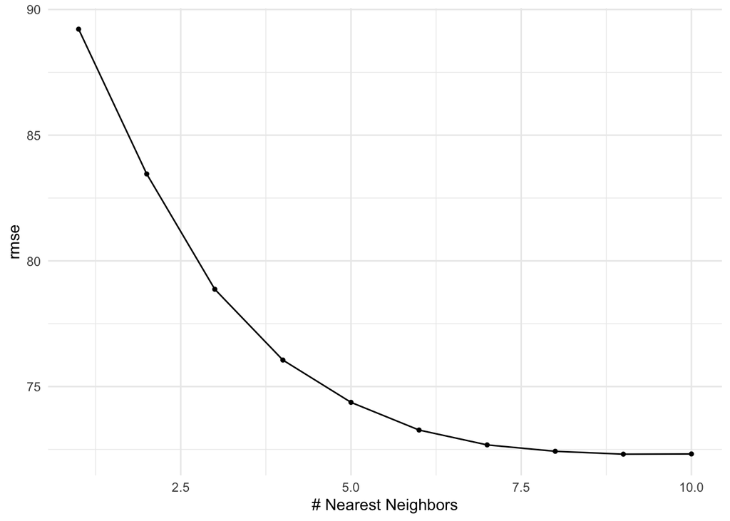

```r
autoplot(knn_tune_res, metric = 'rmse') + theme_minimal()
```

From the plot we can see that as the number of neighbors increases, our model performance increases and the RMSE decreases. But even with 10 neighbors, the RMSE is still around 70.

### Elastic Net

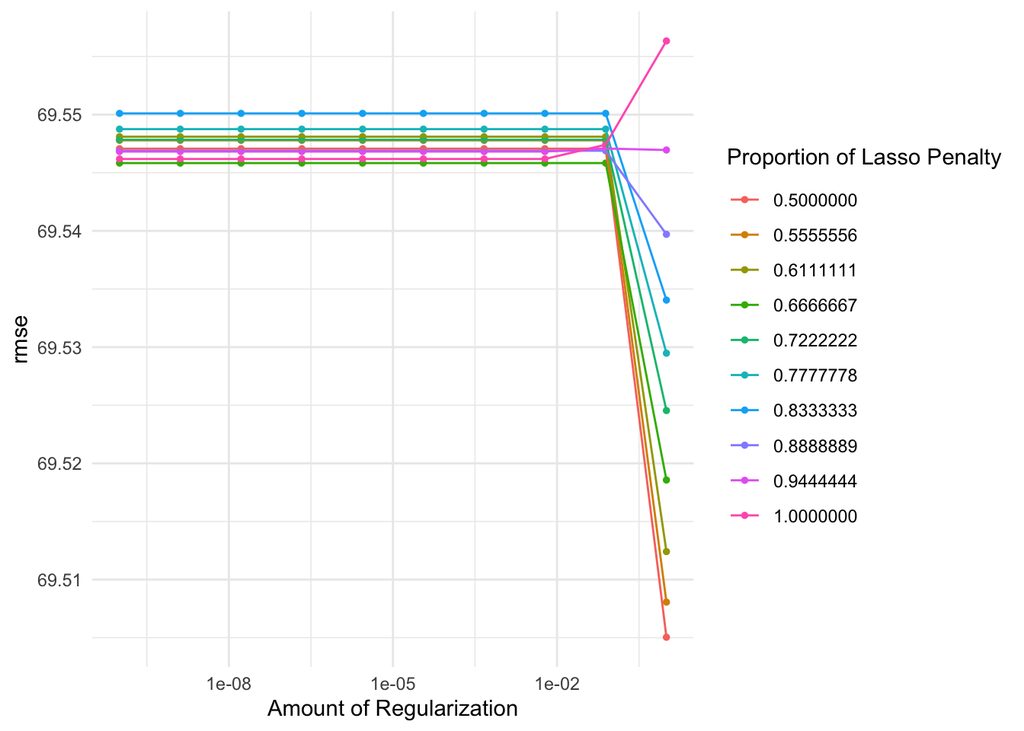

```r
autoplot(en_tune_res, metric = 'rmse') + theme_minimal()
```

We tuned the elastic net model with penalty and mixture at 10 levels. From the plot, it looks like from higher range of penalty value tend to do better. For lower penalty, mid to lower-range of mixture tend to get lower RMSE and as penalty increases, lower mixture values tend to get decreasing RMSE and higher mixture value that’s closer to 1 gets increasing RMSE. So it seems that lower values of mixture only perform better than higher values of mixture when the penalty term is very high.

### Random Forest

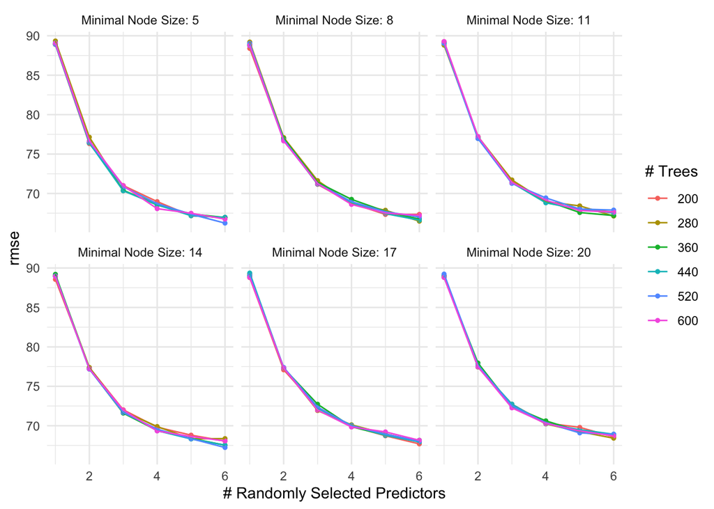

```r
autoplot(rf_tune_res, metric = 'rmse') + theme_minimal()
```

For random forest, we tuned the minimal node size, number trees and number of randomly selected predictors. Since we have 7 predictors in total, I choose the range of mtry to be between 1 and 6 so not all predictors are used in the first split. This is to prevent all trees to have the same first split and keep the trees to be independent from one another. From the plot, it looks like the number of trees doesn’t make much of a difference in the model performance. The minimal node size doesn’t appear to have a huge effect on the performance but lower values of `min_n` appear to have slightly lower RMSE. The number of mtry appear to have a huge affect on model performance, higher number of predictor did significantly better.

### Boosted Tree

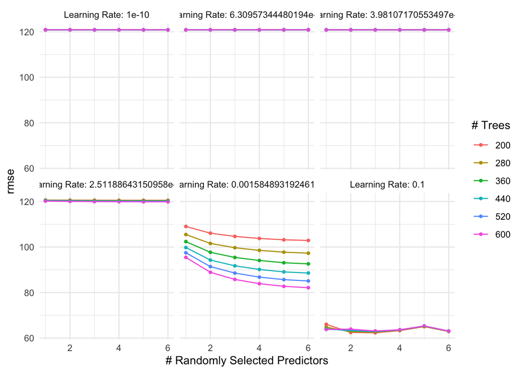

```r
autoplot(bt_tune_reg, metric = 'rmse') + theme_minimal()
```

# Results From the Best Model

So the boosted tree model performed the best out of the 5 models we built.

```r
best_bt_imdb
```

```
## # A tibble: 1 × 9
##    mtry trees learn_rate .metric .estimator  mean     n std_err .config
##   <int> <int>      <dbl> <chr>   <chr>      <dbl> <int>   <dbl> <chr>
## 1     3   200        0.1 rmse    standard    62.3    10    3.99 Preprocessor1_M…
```

Boosted tree #103 with 3 predictors, 200 trees and 0.1 learning rate performed the best with an RMSE of 62.30871!

## Fitting to Training Data

Now, we will take the best performed model and fit it to the training set. This trains our model again on the entire training set.

```r
final_bt_model <- finalize_workflow(bt_workflow, best_bt_imdb)
final_bt_model <- fit(final_bt_model,
                        data = imdb_train)
```

## Fitting to Testing Data

Now let’s take out finalize model and fit it to the testing set to see how well our model performed on unseen data!

```r
# evaluate performance on testing
final_bt_model_test <- augment(final_bt_model, imdb_test) %>%
  rmse(truth = gross, estimate = .pred)

final_bt_model_test
```

```
## # A tibble: 1 × 3
##   .metric .estimator .estimate
##   <chr>   <chr>          <dbl>
## 1 rmse    standard        84.5
```

Looks like our boosted tree model actually performed worse on the testing set than the cross-validation set with RMSE of 84.5!

# Visualizing Final Model Performance

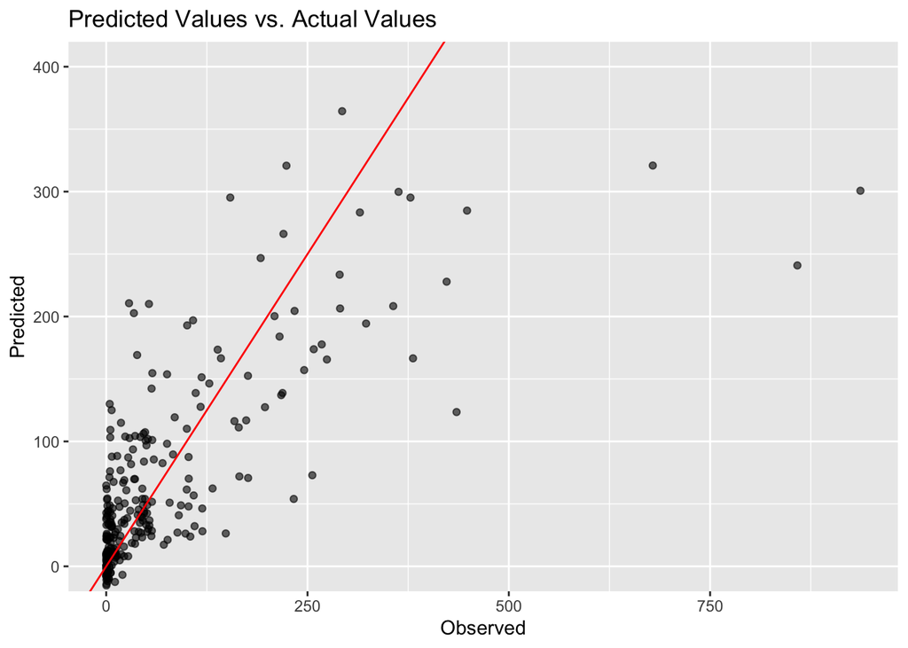

```r
# create a tibble of predicted and actual gross
imdb_tibble <- predict(final_bt_model, new_data = imdb_test %>% select(-gross))
imdb_tibble <- bind_cols(imdb_tibble, imdb_test %>% select(gross))

imdb_tibble %>%
  ggplot(aes(x = gross, y =.pred)) +
  geom_point(alpha = 0.6) +
  geom_abline(color='red') +
  coord_cartesian(ylim=c(0,400)) +
  labs(title = "Predicted Values vs. Actual Values",
       x="Observed",
       y="Predicted")
```

If our model predicted every observation accurately, the points would form a straight line. However, from the plot we can see that very few points fall on the line, especially when gross gets larger. That makes sense since we have very little data for when gross revenue goes over 250 million. It looks like our model didn’t really performed well since many points didn’t follow the line.

# Conclusion

After fitting and analyzing 5 different types of models, the best model to predict gross revenue of movies is the boosted tree model. This is not surprising since boosted tree models tend to do good for a wide range of data types and tend to handle high-dimensional data well. However, this model still didn’t perform well in predicting the gross revenue of movies. Overall, our model produces a higher RMSE on the testing set compared to the cross-validation set, this indicates that the model may not generalize as well to unseen data. It also suggests that the model might be over-fitting to the training data, it captures noise in the training data rather than the underlying pattern.

For future research, I would like to explore more predictors such as authors and directors to see how the popularity of these figures featured in film can affect its success. I believe the low correlation between the predictors used and `gross` might contribute to the model performance, since only number of votes have a significant correlation with `gross`. I would also like to explore more models and try out different modeling techniques. Although this model did not perform quite well, I still find this project very interesting. This was a great opportunity for me to build my machine learning modeling skills while gaining valuable insights about movies in general.

# Sources

The data set was taken from [Kaggle](https://www.kaggle.com/datasets/harshitshankhdhar/imdb-dataset-of-top-1000-movies-and-tv-shows), by user HARSHIT SHANKHDHAR. The data was extracted from the IMDB website.

Information about certificate types were found on wikipedia. ([CBFC](https://en.wikipedia.org/wiki/Central_Board_of_Film_Certification), [MPAA Film](https://en.wikipedia.org/wiki/Motion_Picture_Association_film_rating_system) and [MPAA TV](https://en.wikipedia.org/wiki/TV_Parental_Guidelines))